# stat387

Mina Mehdinia, Tim Luo, Will McIntosh

2023-03-01

# Exploratory

```
##     Default      checking            duration      history
##  Min.   :0.0   Length:1000        Min.   : 4.0   Length:1000
##  1st Qu.:0.0   Class :character   1st Qu.:12.0   Class :character
##  Median :0.0   Mode  :character   Median :18.0   Mode  :character
##  Mean   :0.3                      Mean   :20.9
##  3rd Qu.:1.0                      3rd Qu.:24.0
##  Max.   :1.0                      Max.   :72.0
##    purpose              amount        savings             employ
##  Length:1000        Min.   :  250   Length:1000        Length:1000
##  Class :character   1st Qu.: 1366   Class :character   Class :character
##  Mode  :character   Median : 2320   Mode  :character   Mode  :character
##                     Mean   : 3271
##                     3rd Qu.: 3972
##                     Max.   :18424
##   installment       status             others            residence
##  Min.   :1.000   Length:1000        Length:1000        Min.   :1.000
##  1st Qu.:2.000   Class :character   Class :character   1st Qu.:2.000
##  Median :3.000   Mode  :character   Mode  :character   Median :3.000
##  Mean   :2.973                                         Mean   :2.845
##  3rd Qu.:4.000                                         3rd Qu.:4.000
##  Max.   :4.000                                         Max.   :4.000
##    property              age         otherplans          housing
##  Length:1000        Min.   :19.00   Length:1000        Length:1000
##  Class :character   1st Qu.:27.00   Class :character   Class :character
##  Mode  :character   Median :33.00   Mode  :character   Mode  :character
##                     Mean   :35.55
##                     3rd Qu.:42.00
##                     Max.   :75.00
##      cards           job                liable          tele
##  Min.   :1.000   Length:1000        Min.   :1.000   Length:1000
##  1st Qu.:1.000   Class :character   1st Qu.:1.000   Class :character
##  Median :1.000   Mode  :character   Median :1.000   Mode  :character
##  Mean   :1.407                      Mean   :1.155
##  3rd Qu.:2.000                      3rd Qu.:1.000
##  Max.   :4.000                      Max.   :2.000
##    foreign
##  Length:1000
##  Class :character
##  Mode  :character
##
##
##
```

The `german` dataset contains data about loan applicants (borrower) of a German credit institution from 1994. There are 1,000 observations and 21 variables, of which 13 are categorical and 8 are numeric. Each observation represents one customer. Categorical Variables * checking - Status of existing checking account * history - Credit history of borrower * purpose - Purpose of loan application * savings - Status of savings/bonds account * employ - Current length of employment * status - Marital status and sex * others - Indicate if someone else will be involved in the repayment or is guaranteeing the loan * property - Collateral for loan * otherplans - Type of installment plans the borrower already has * housing - Residential status of borrower * job - Current type of employment * tele - Indicate if phone number is registered under the borrower’s name * foreign - Indicate if the borrower is a foreign worker

Numeric Variables * Default - Specify if the borrower fully repaid their loan * duration - Duration of loan (in months) * amount - Amount of money borrowed (DM) * installment - percentage of amount borrowed that will be charged by a lender to a borrower * residence - Length of time living at current residence (in years, 4 = 4+) * age - age of customer (in years) * cards - Number of existing credits at this bank * liable - Number of people being liable to provide maintenance for

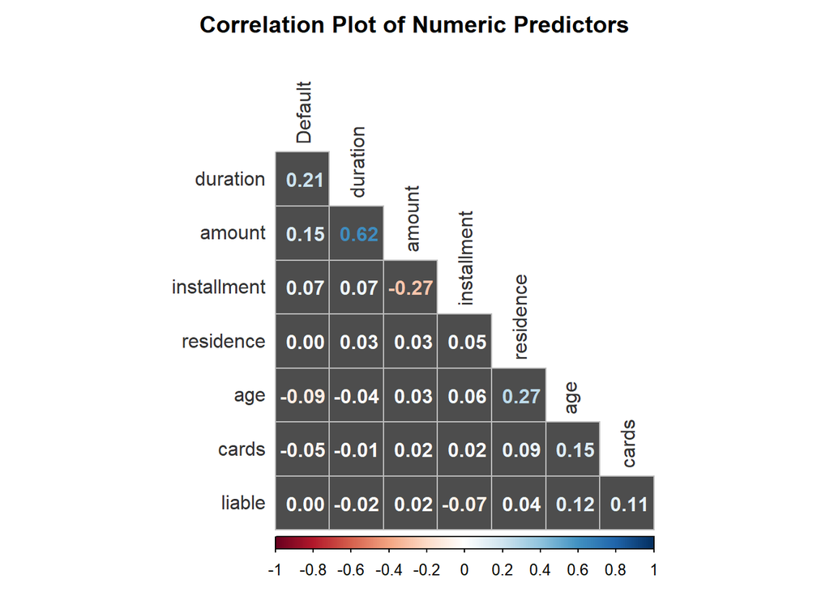

```
##
## Call:
## glm(formula = Default ~ checking + duration + history + purpose +
##     amount + savings + installment + otherplans, family = "binomial",
##     data = german)
##
## Deviance Residuals:
##     Min       1Q   Median       3Q      Max
## -2.2312  -0.7569  -0.4274   0.8152   2.6255
##
## Coefficients:
##                  Estimate Std. Error z value Pr(>|z|)
## (Intercept)     1.996e-01  5.288e-01   0.377 0.705816
## checkingA12    -3.581e-01  2.027e-01  -1.767 0.077298 .
## checkingA13    -9.632e-01  3.506e-01  -2.747 0.006008 **
## checkingA14    -1.705e+00  2.220e-01  -7.681 1.58e-14 ***
## duration        2.872e-02  8.622e-03   3.331 0.000865 ***
## historyA31     -1.160e-01  5.074e-01  -0.229 0.819140
## historyA32     -7.897e-01  3.951e-01  -1.999 0.045618 *
## historyA33     -9.607e-01  4.532e-01  -2.120 0.034034 *
## historyA34     -1.580e+00  4.169e-01  -3.790 0.000150 ***
## purposeA41     -1.545e+00  3.522e-01  -4.385 1.16e-05 ***
## purposeA410    -1.472e+00  7.178e-01  -2.051 0.040231 *
## purposeA42     -5.258e-01  2.413e-01  -2.179 0.029367 *
## purposeA43     -8.775e-01  2.315e-01  -3.790 0.000151 ***
## purposeA44     -3.293e-01  7.256e-01  -0.454 0.649949
## purposeA45     -1.913e-01  5.237e-01  -0.365 0.714931
## purposeA46      2.980e-01  3.786e-01   0.787 0.431236
## purposeA48     -1.878e+00  1.179e+00  -1.592 0.111307
## purposeA49     -7.170e-01  3.155e-01  -2.273 0.023025 *
## amount          1.011e-04  3.972e-05   2.544 0.010957 *
## savingsA62     -2.307e-01  2.694e-01  -0.857 0.391678
## savingsA63     -4.060e-01  3.900e-01  -1.041 0.297882
## savingsA64     -1.163e+00  4.950e-01  -2.348 0.018853 *
## savingsA65     -9.592e-01  2.486e-01  -3.858 0.000114 ***
## installment     2.708e-01  8.109e-02   3.340 0.000838 ***
## otherplansA142 -6.262e-02  3.944e-01  -0.159 0.873842
## otherplansA143 -5.228e-01  2.279e-01  -2.294 0.021774 *
## ---
## Signif. codes:  0 '***' 0.001 '**' 0.01 '*' 0.05 '.' 0.1 ' ' 1
##
## (Dispersion parameter for binomial family taken to be 1)
##
##     Null deviance: 1221.73  on 999  degrees of freedom
## Residual deviance:  951.01  on 974  degrees of freedom
## AIC: 1003
##
## Number of Fisher Scoring iterations: 5
```

```
##   Var1 Var2 Freq
## 1    0    0  651
## 2    1    0   49
## 3    0    1  286
## 4    1    1   14
```

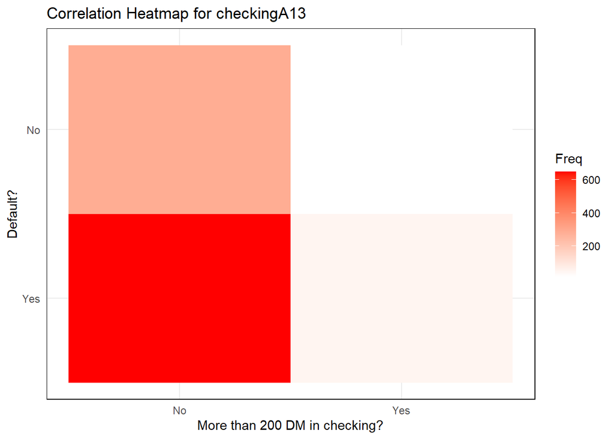

```
##   Var1 Var2 Freq
## 1    0    0  352
## 2    1    0  348
## 3    0    1  254
## 4    1    1   46
```

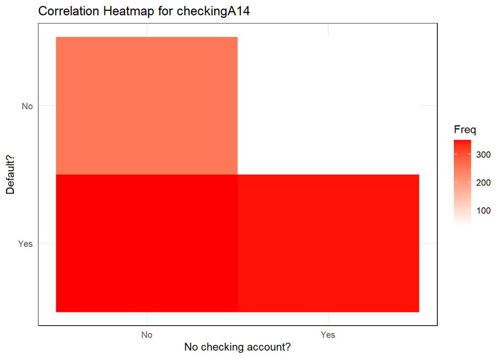

```
##    Var1 Var2 Freq
## 1     4    0    6
## 2     5    0    1
## 3     6    0   66
## 4     7    0    5
## 5     8    0    6
## 6     9    0   35
## 7    10    0   25
## 8    11    0    9
## 9    12    0  130
## 10   13    0    4
## 11   14    0    3
## 12   15    0   52
## 13   16    0    1
## 14   18    0   71
```

[output cut: 52 more lines]

[figure not shown]

```
##   Var1 Var2 Freq
## 1    0    0  457
## 2    1    0  243
## 3    0    1  250
## 4    1    1   50
```

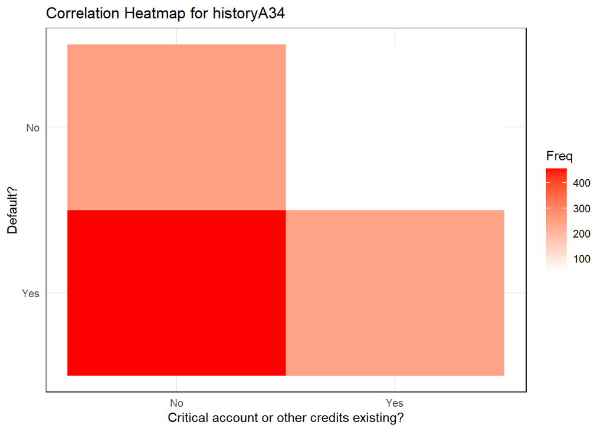

```
##   Var1 Var2 Freq
## 1    0    0  614
## 2    1    0   86
## 3    0    1  283
## 4    1    1   17
```

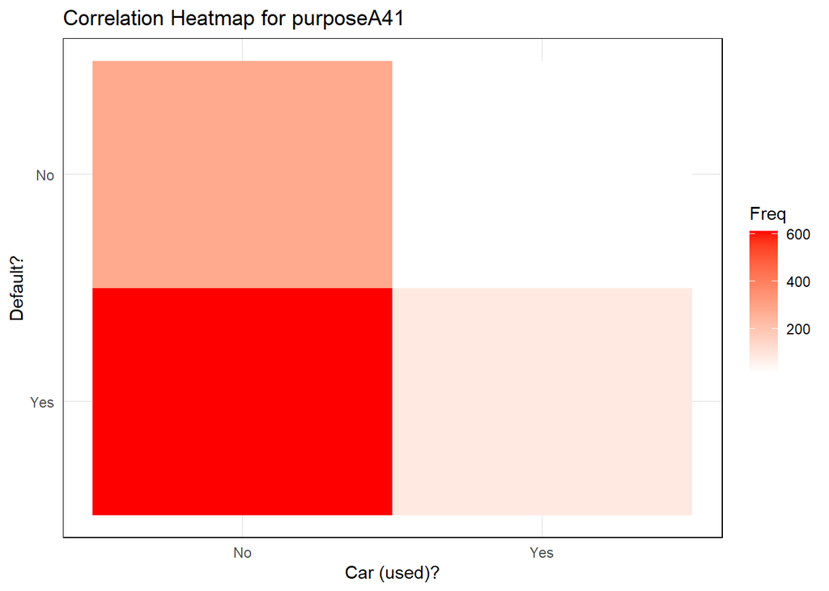

```
##   Var1 Var2 Freq
## 1    0    0  577
## 2    1    0  123
## 3    0    1  242
## 4    1    1   58
```

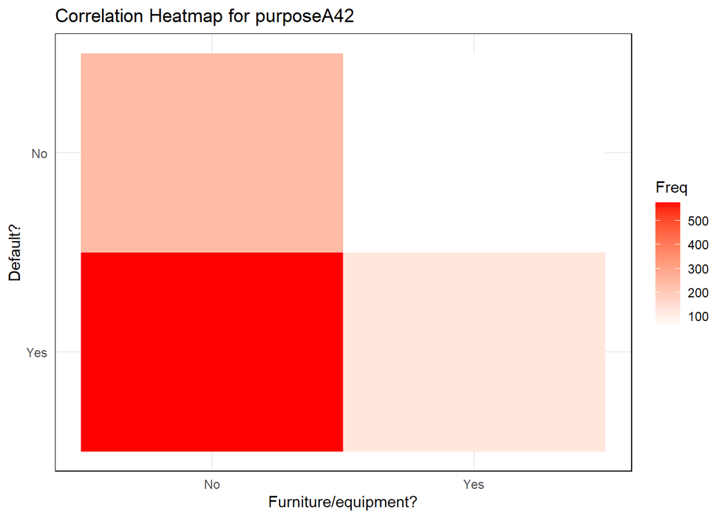

```
##   Var1 Var2 Freq
## 1    0    0  482
## 2    1    0  218
## 3    0    1  238
## 4    1    1   62
```

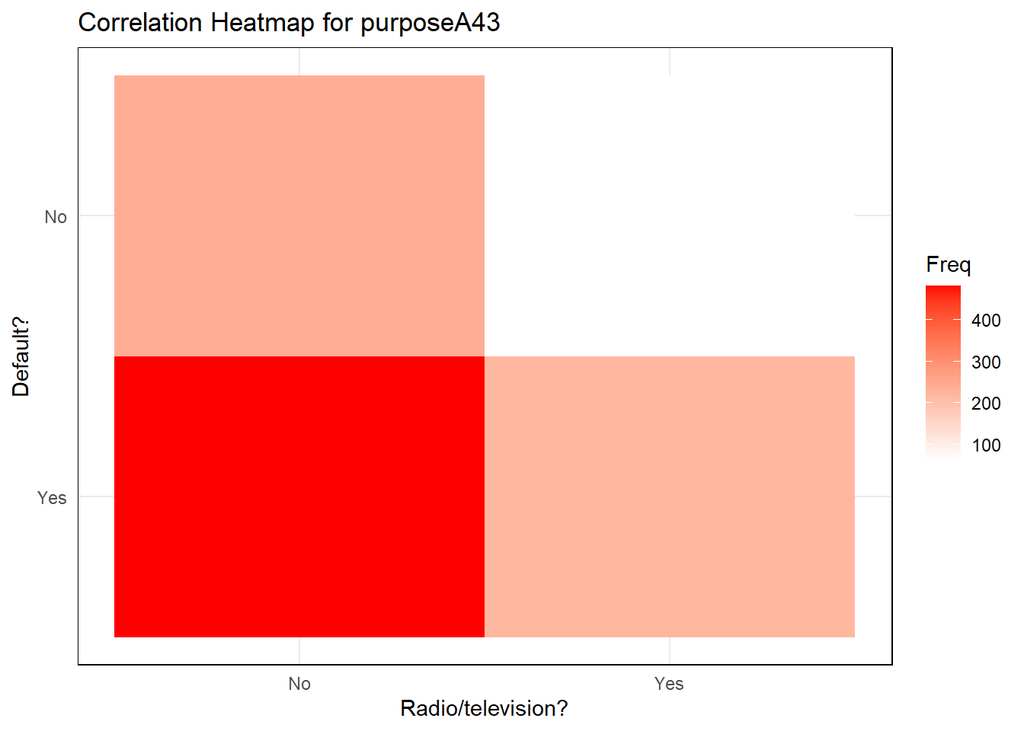

```
##   Var1 Var2 Freq
## 1    0    0  637
## 2    1    0   63
## 3    0    1  266
## 4    1    1   34
```

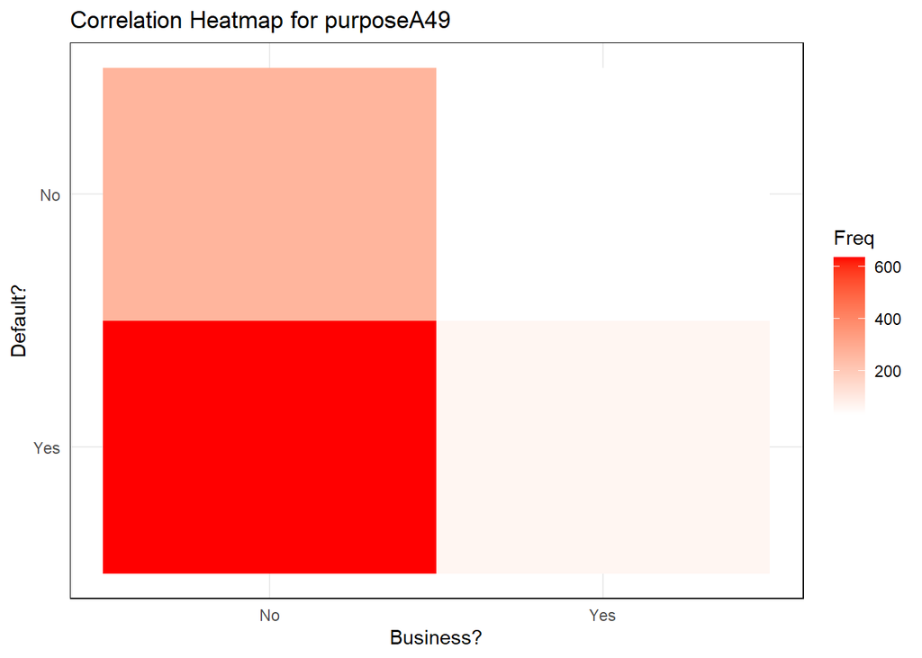

```
##       Var1 Var2 Freq
## 1      250    0    1
## 2      276    0    1
## 3      338    0    1
## 4      339    0    1
## 5      343    0    1
## 6      362    0    1
## 7      368    0    1
## 8      385    0    1
## 9      392    0    1
## 10     409    0    1
## 11     426    0    1
## 12     428    0    1
## 13     433    0    0
## 14     448    0    0
```

[output cut: 1828 more lines]

[figure not shown]

```
##   Var1 Var2 Freq
## 1    0    0  658
## 2    1    0   42
## 3    0    1  294
## 4    1    1    6
```

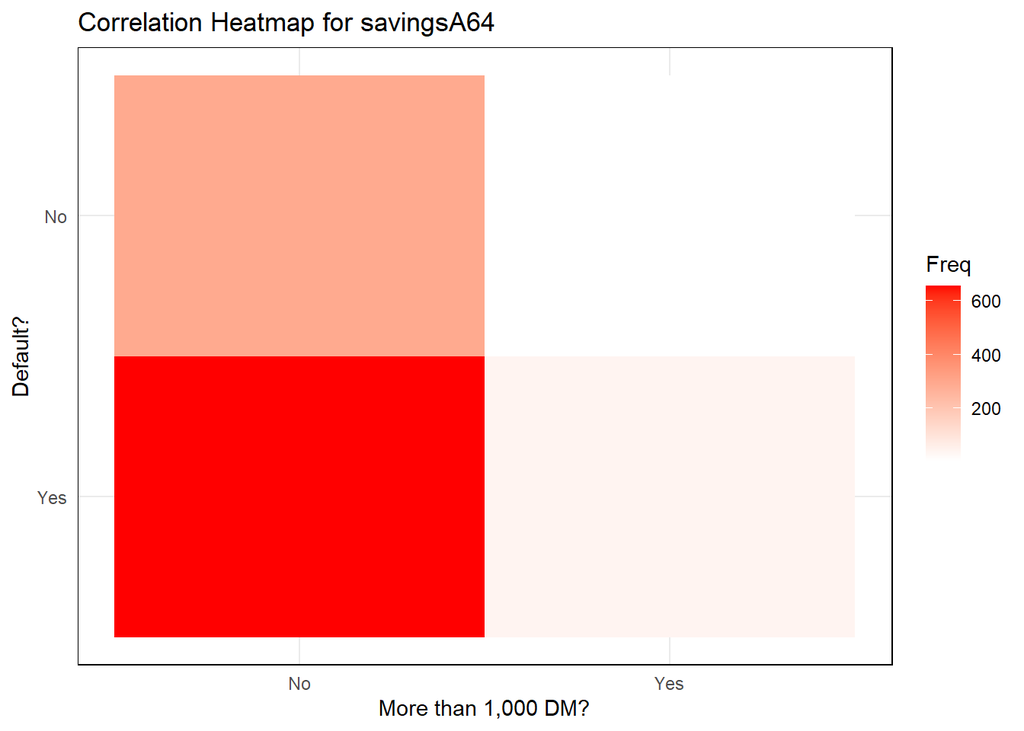

```
##   Var1 Var2 Freq
## 1    0    0  549
## 2    1    0  151
## 3    0    1  268
## 4    1    1   32
```

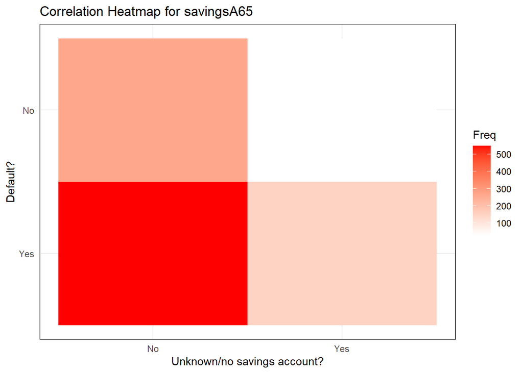

```
##   Var1 Var2 Freq
## 1    1    0  102
## 2    2    0  169
## 3    3    0  112
## 4    4    0  317
## 5    1    1   34
## 6    2    1   62
## 7    3    1   45
## 8    4    1  159
```

[figure not shown]

```
##   Var1 Var2 Freq
## 1    0    0  298
## 2    1    0  402
## 3    0    1  154
## 4    1    1  146
```

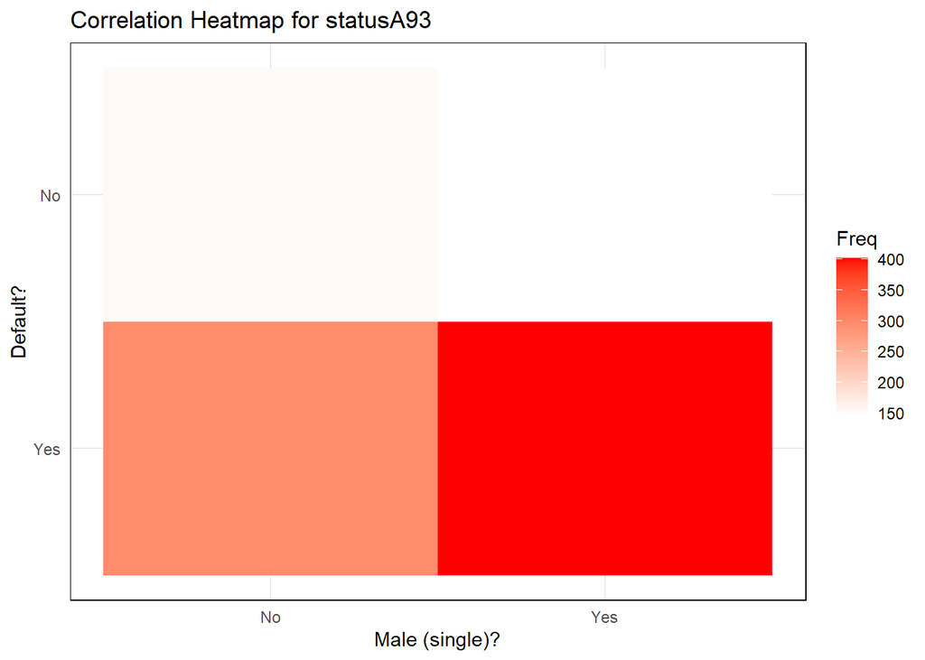

```
##   Var1 Var2 Freq
## 1    0    0  658
## 2    1    0   42
## 3    0    1  290
## 4    1    1   10
```

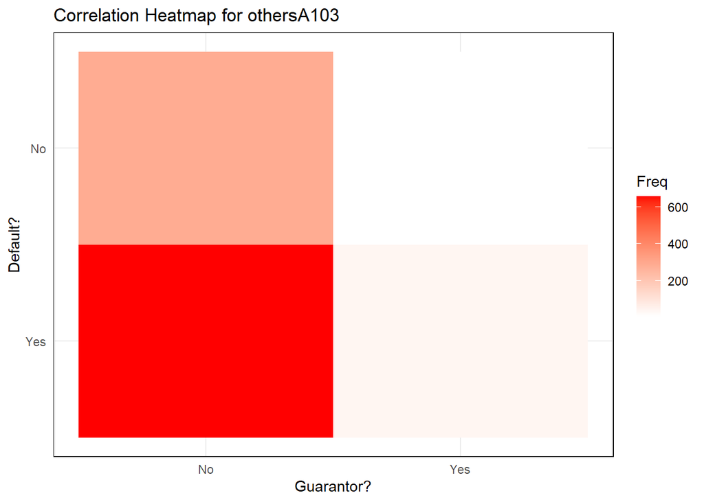

```
##   Var1 Var2 Freq
## 1    0    0  110
## 2    1    0  590
## 3    0    1   76
## 4    1    1  224
```

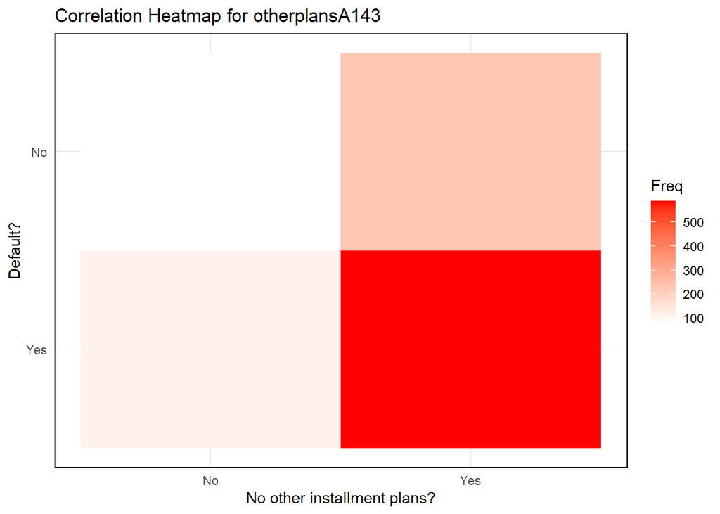

```
##   Var1 Var2 Freq
## 1    0    0  667
## 2    1    0   33
## 3    0    1  296
## 4    1    1    4
```

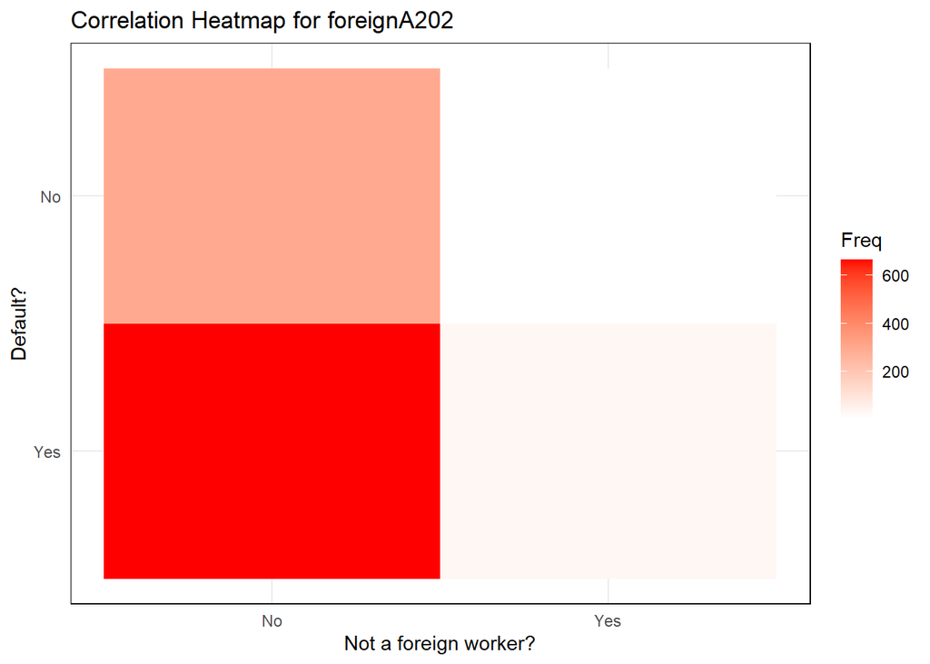

# One-Hot Encoding

Below I am making dummy variables (or one-hot encodings) of the categorical variables (WMM - 3/2/23).

```
##   Default checkingA11 checkingA12 checkingA13 checkingA14 duration historyA30
## 1       0           1           0           0           0        6          0
## 2       1           0           1           0           0       48          0
## 3       0           0           0           0           1       12          0
## 4       0           1           0           0           0       42          0
## 5       1           1           0           0           0       24          0
## 6       0           0           0           0           1       36          0
##   historyA31 historyA32 historyA33 historyA34 purposeA40 purposeA41 purposeA410
## 1          0          0          0          1          0          0           0
## 2          0          1          0          0          0          0           0
## 3          0          0          0          1          0          0           0
## 4          0          1          0          0          0          0           0
## 5          0          0          1          0          1          0           0
## 6          0          1          0          0          0          0           0
##   purposeA42 purposeA43 purposeA44 purposeA45 purposeA46 purposeA48 purposeA49
```

[output cut: 48 more lines]

# Value Counts For Each Class Type

## Plotting Checking Status Count Per Class

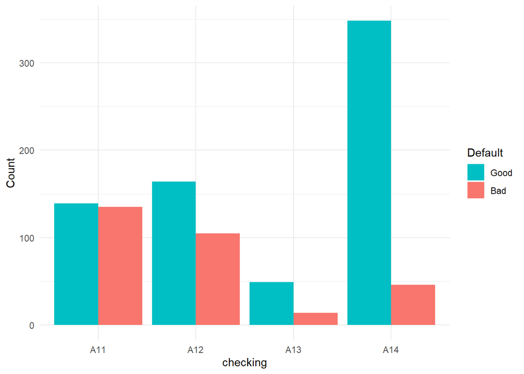

## Plotting History Count Per Class

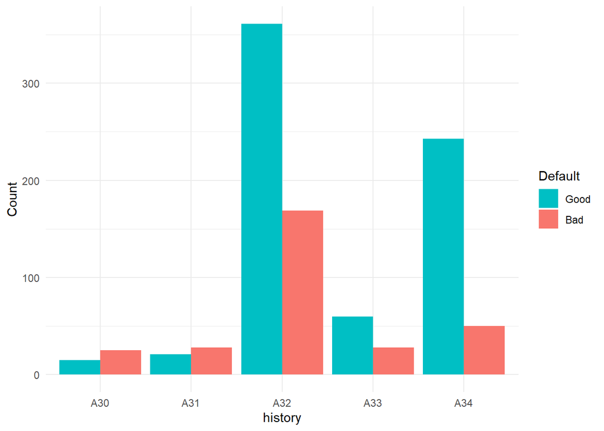

## Plotting Purpose Count Per Class

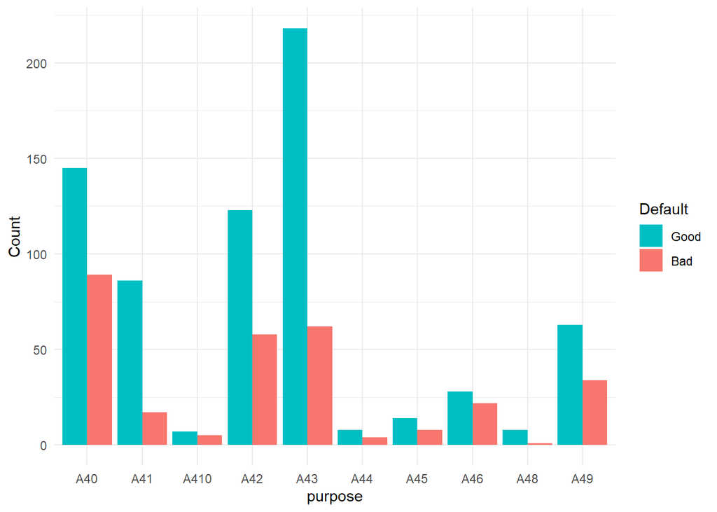

## Plotting Savings Count Per Class

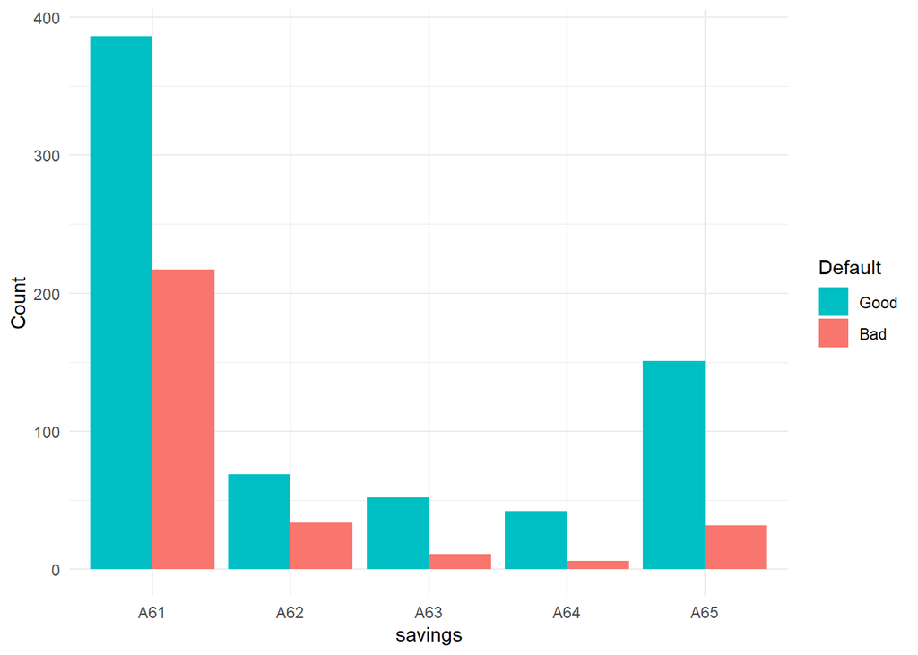

## Plotting Employ Count Per Class

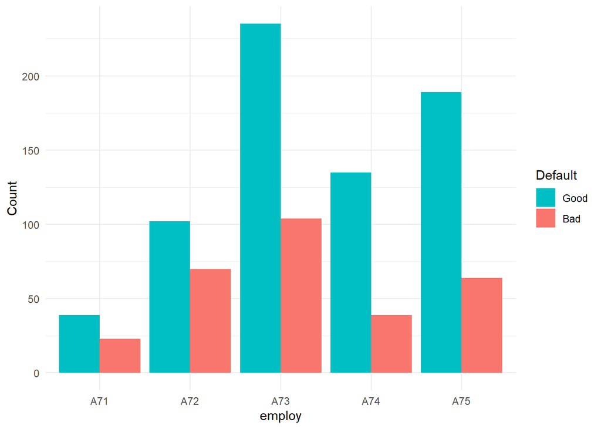

# Displaying Duration For Each Class

# Displaying Amount For Each Class

[figure not shown]

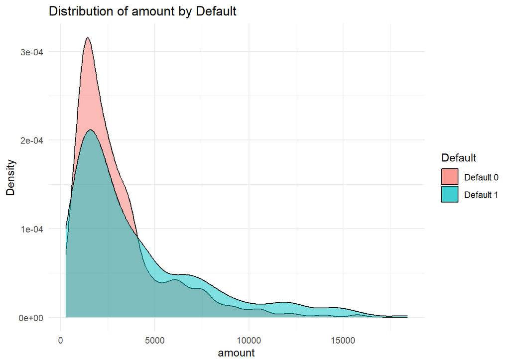

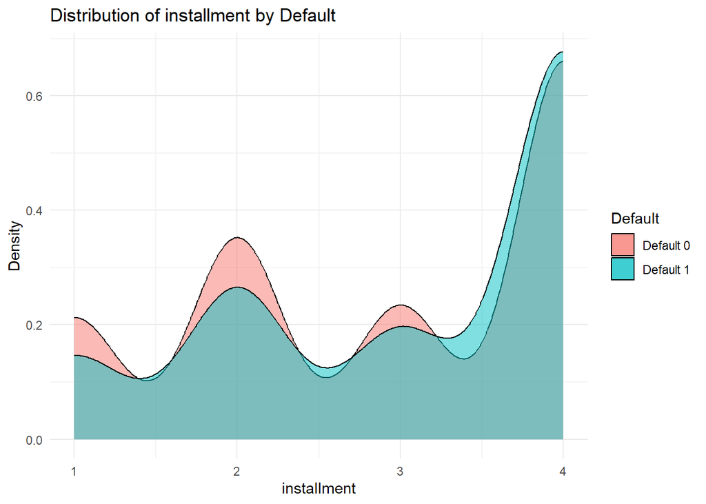

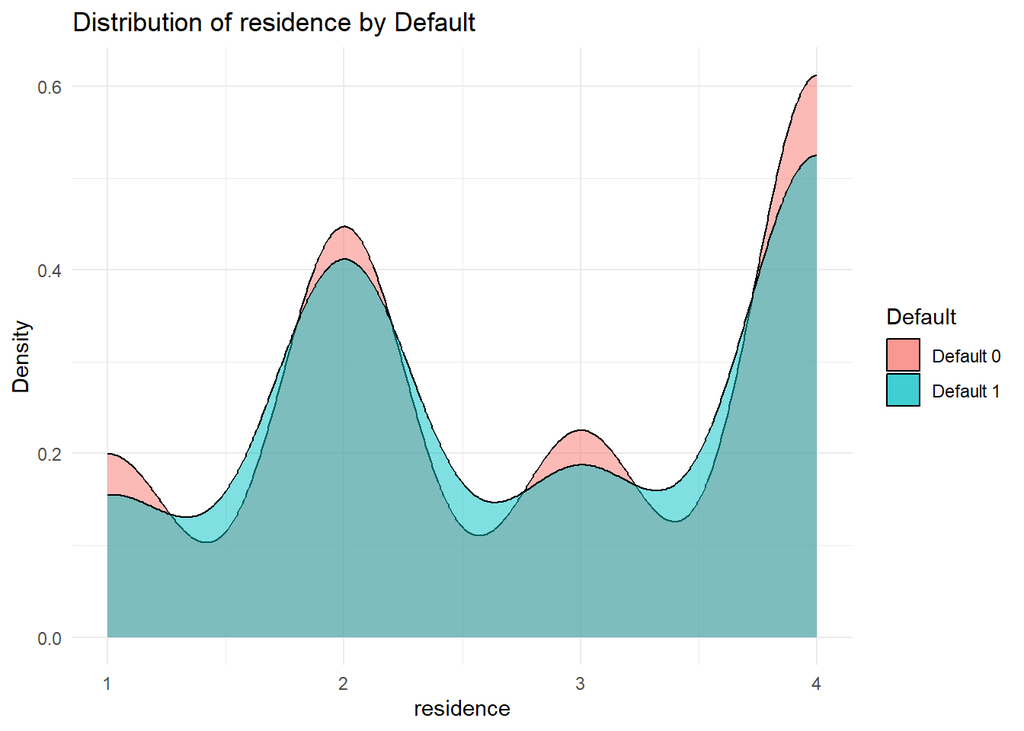

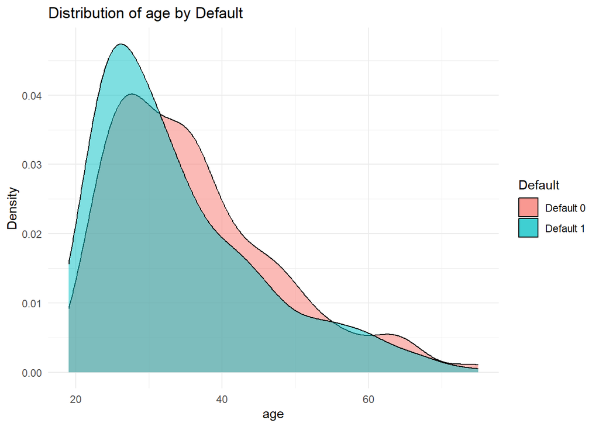

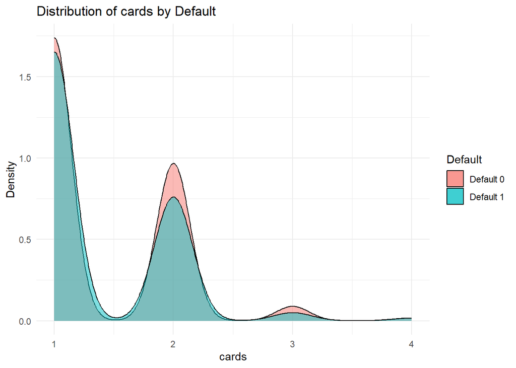

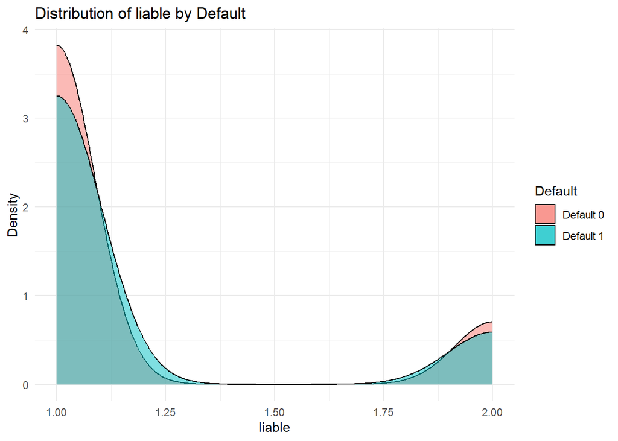

# One-Hot Encoding

Below I am making dummy variables (or one-hot encodings) of the categorical variables.

```
##   Default checkingA11 checkingA12 checkingA13 checkingA14 duration historyA30
## 1       0           1           0           0           0        6          0
## 2       1           0           1           0           0       48          0
## 3       0           0           0           0           1       12          0
## 4       0           1           0           0           0       42          0
## 5       1           1           0           0           0       24          0
## 6       0           0           0           0           1       36          0
##   historyA31 historyA32 historyA33 historyA34 purposeA40 purposeA41 purposeA410
## 1          0          0          0          1          0          0           0
## 2          0          1          0          0          0          0           0
## 3          0          0          0          1          0          0           0
## 4          0          1          0          0          0          0           0
## 5          0          0          1          0          1          0           0
## 6          0          1          0          0          0          0           0
##   purposeA42 purposeA43 purposeA44 purposeA45 purposeA46 purposeA48 purposeA49
```

[output cut: 48 more lines]

# RFE

```
##
## Recursive feature selection
##
## Outer resampling method: Cross-Validated (10 fold)
##
## Resampling performance over subset size:
##
##  Variables Accuracy   Kappa AccuracySD KappaSD Selected
##          1    0.680 0.01651    0.04619 0.05552
##          2    0.713 0.23061    0.04572 0.12224
##          3    0.735 0.28645    0.03308 0.07099
##          4    0.734 0.31412    0.04351 0.11640
##         20    0.779 0.41510    0.04383 0.10773        *
##
## The top 5 variables (out of 20):
##    checking, duration, history, amount, savings
```

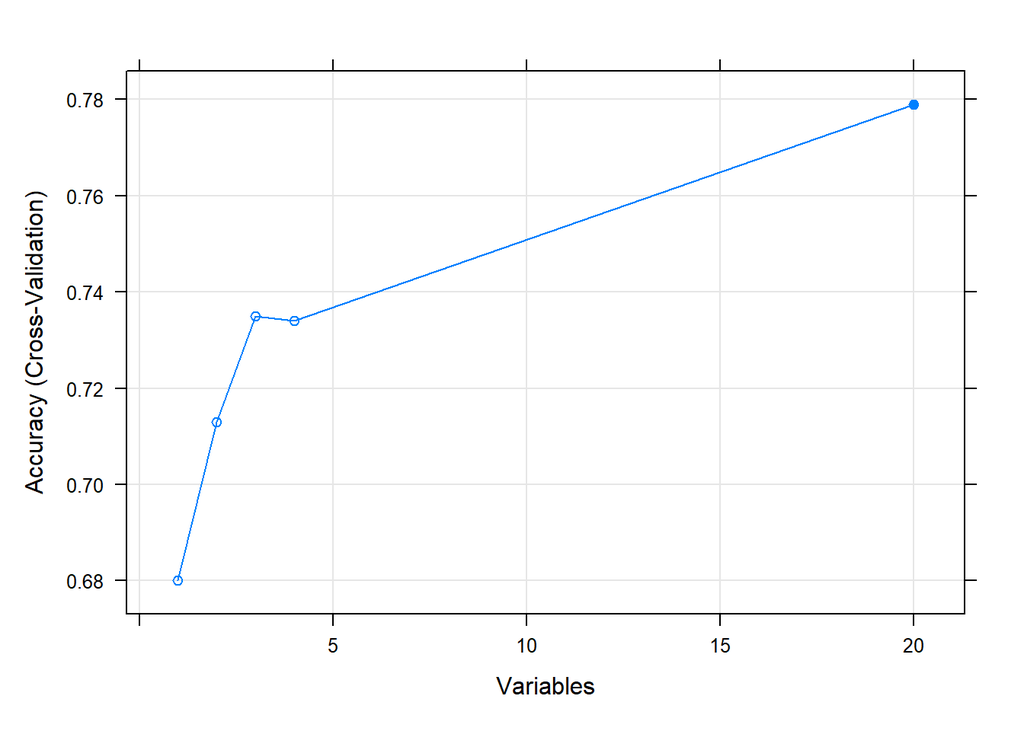

## Running RFE on Dummy-Variabled German Data

```
##
## Recursive feature selection
##
## Outer resampling method: Cross-Validated (10 fold)
##
## Resampling performance over subset size:
##
##  Variables Accuracy   Kappa AccuracySD KappaSD Selected
##          1    0.700 0.00000    0.00000 0.00000
##          2    0.703 0.03918    0.01337 0.08685
##          3    0.704 0.09172    0.04195 0.10404
##          4    0.720 0.23567    0.04055 0.13006
##         61    0.770 0.36829    0.02494 0.07772        *
##
## The top 5 variables (out of 61):
##    checkingA14, checkingA11, duration, historyA34, amount
```

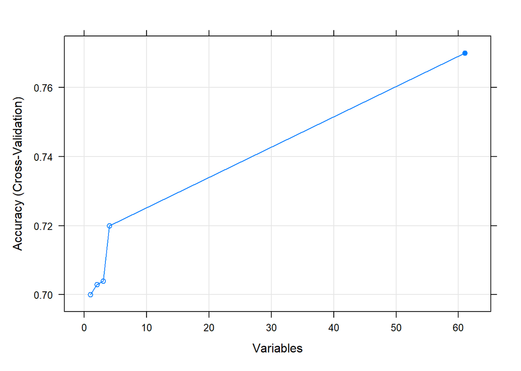

## Running RFE on Dummy-Variabled German Data with Only 2 Variables

```
##
## Recursive feature selection
##
## Outer resampling method: Cross-Validated (10 fold)
##
## Resampling performance over subset size:
##
##  Variables Accuracy   Kappa AccuracySD KappaSD Selected
##          1    0.700 0.00000    0.00000 0.00000
##          2    0.705 0.03923    0.01269 0.08473
##         61    0.779 0.40585    0.03414 0.08622        *
##
## The top 5 variables (out of 61):
##    checkingA14, checkingA11, duration, historyA34, amount
```

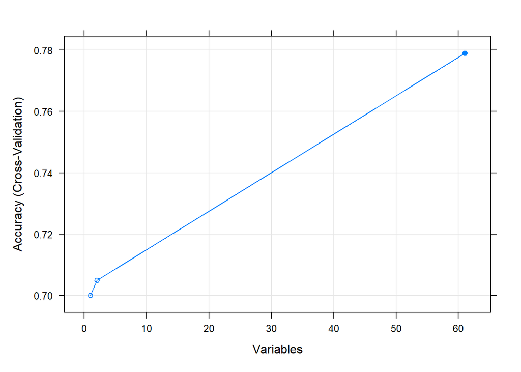